# Soluciones 3

Sergio Camiz

2025-05-05

```r
options(width = 300)                                        # ancho de página
```

## 1 Construir una carpeta Ejercicio_3

*Hecho*

```r
setwd("/Work/Lavoro/PUCP/Corso PUCP 2025 - Modelo Lineal/Lezioni 2025/Clase_3 - Regresión múltiple/Esercizi")                            # carpeta de trabajo
```

## 2 Cargar desde Paideia:

```
  Instrucciones 3.R
  lin.csv : condiciónes físicas y prestaciones de 20 atletas
  Decathlon.csv : diez pruebas de decathlon y puntaje global
y colocarlos en Rstudio como siempre
```

*se leen los datos de lin y de Decathlon*

```r
lin                 <- read.csv("Linnerud.csv",row.names=1)
head(lin)
```

```
##   Weight Waist Pulse Pulls Squats Jumps
## 1    191    36    50     5    162    60
## 2    189    37    52     2    110    60
## 3    193    38    58    12    101   101
## 4    162    35    62    12    105    37
## 5    189    35    46    13    155    58
## 6    182    36    56     4    101    42
```

```r
dec                 <- read.csv("Decathlon.csv",row.names=1)
head(dec)
```

```
##           X100m Long.jump Shot.put High.jump X400m X110m.hurdle Discus Pole.vault Javeline X1500m Points
## Sebrle    10.85      7.84    16.36      2.12 48.36        14.05  48.72        5.0    70.52 280.01   8893
## Clay      10.44      7.96    15.23      2.06 49.19        14.13  50.11        4.9    69.71 282.00   8820
## Karpov    10.50      7.81    15.93      2.09 46.81        13.97  51.65        4.6    55.54 278.11   8725
## Macey     10.89      7.47    15.73      2.15 48.97        14.56  48.34        4.4    58.46 265.42   8414
## Warners   10.62      7.74    14.48      1.97 47.97        14.01  43.73        4.9    55.39 278.05   8343
## Zsivoczky 10.91      7.14    15.31      2.12 49.40        14.95  45.62        4.7    63.45 269.54   8287
```

*se carga la Clase_3 en un pedazo y se limpia un poco*

*Hecho*

## 3 Emplear las instrucciones para modelar,

del archivo Linnerud, “Pulls” utilizando “Weight”, “Waist” y “Pulse”, con gráficos correspondientes.

```r
y     <- lin$Pulls                           # criterio
x     <- as.matrix(lin[,1:3])                # x matriz de regresores
# definición de los datos para el modelo
lab   <- rownames(x)
n     <- length(y)                           # n es el número de observaciones
p     <- dim(x)[2]                           # numero de regresores
nomy  <- deparse(substitute(y))              # nomy es su nombre
nom   <- c(colnames(x),nomy)                 # etiquetas variables en nom
# estadísticas
xm    <- apply(x,2,mean)                     # cálculo de xm, promedio de x
ym    <- sum(y)/n                            # cálculo de ym, promedio de y
ssx   <- apply(x^2,2,sum)                    # ssx es la suma de los x cuadros
ssy   <- sum(y^2)                            # ssy es la suma de los y cuadros
sxy   <- t(x)%*%y                            # sxy es la suma de los productos xy
ssxc  <- ssx-n*xm^2                          # ssxc es ssx centrado sobre el promedio
ssyc  <- ssy-n*ym^2                          # ssyc es ssy centrado sobre el promedio
sxyc  <- sxy-n*xm*ym                         # sxyc es sxy centrado sobre el promedio
varx  <- ssxc/n                              # varx es la varianza de x
vary  <- ssyc/n                              # vary es la varianza de y
covxy <- sxyc/n                              # covxy es la covarianza de xy
stats <- matrix(8*(2*p+1)*0,nrow=8,ncol=(2*p+1)) # construcción de tabla de estadísticas
rownames(stats) <- c("Mínimo","Máximo","Promedio","Total","Suma de cuadrados",
                    "Cuadrados centrados","Varianza covarianza","Desvío estándar")
colnames(stats) <- c(nom,"x1y","x2y","x3y")
stats[1:8,1:p] <- rbind(apply(x,2,min),apply(x,2,max),xm,apply(x,2,sum),ssx,ssxc,varx,sqrt(varx))
stats[,p+1] <- rbind(min(y),max(y),ym,sum(y),ssy,ssyc,vary,sqrt(vary))
stats[,c((p+2):(2*p+1))] <- rbind(t(rep(0,p)),t(rep(0,p)),t(rep(0,p)),t(rep(0,p)),t(sxy),t(sxyc),t(covxy),t(rep(0,p)))
cat("\n Estadísticas \n")
```

```
##
##  Estadísticas
```

```r
round(stats,3)                               # impresión de la tabla
```

```
##                         Weight     Waist     Pulse        y      x1y     x2y       x3y
## Mínimo                 138.000    31.000    46.000    1.000     0.00    0.00     0.000
## Máximo                 247.000    46.000    74.000   17.000     0.00    0.00     0.000
## Promedio               178.600    35.400    56.100    9.450     0.00    0.00     0.000
## Total                 3572.000   708.000  1122.000  189.000     0.00    0.00     0.000
## Suma de cuadrados   649542.000 25258.000 63932.000 2317.000 32789.00 6513.00 10712.000
## Cuadrados centrados  11582.800   194.800   987.800  530.950  -966.40 -177.60   109.100
## Varianza covarianza    579.140     9.740    49.390   26.548   -48.32   -8.88     5.455
## Desvío estándar         24.065     3.121     7.028    5.152     0.00    0.00     0.000
```

```r
cat("\n Matriz de varianza y covarianza de los regresores \n")
```

```
##
##  Matriz de varianza y covarianza de los regresores
```

```r
vcovx <- (n-1)/n * cov(x)                    # matriz de varianza/covarianza de los x
# estimación
X      <- cbind(rep(1,n),x)                  # se necesita ajuntar la columna de unos
p1     <- p + 1                              # un regresor más
XX     <- t(X)%*%X                           # matriz X'X
XXm1   <- solve(XX)                          # su inversa
bh     <- XXm1 %*% t(X) %*% y                # estimación de los betas
cat("\n Estimaciones de los beta \n")
```

```
##
##  Estimaciones de los beta
```

```r
bh
```

```
##               [,1]
##        47.96841291
## Weight  0.07884384
## Waist  -1.45584256
## Pulse  -0.01895002
```

```r
eta    <- X %*% bh                           # valores estimados
res    <- y - eta                            # residuos
unidad <- cbind(x,y,eta,res)                 # tabla de resultados
rownames(unidad) <- lab
colnames(unidad) <- c(nom,"eta","residuos")
cat("\n Estimaciones \n")
```

```
##
##  Estimaciones
```

```r
round(unidad,3)                              # impresión de la tabla
```

```
##    Weight Waist Pulse  y    eta residuos
## 1     191    36    50  5  9.670   -4.670
## 2     189    37    52  2  8.018   -6.018
## 3     193    38    58 12  6.764    5.236
## 4     162    35    62 12  8.612    3.388
## 5     189    35    46 13 11.044    1.956
## 6     182    36    56  4  8.846   -4.846
## 7     211    38    56  8  8.221   -0.221
## 8     167    34    60  6 10.500   -4.500
## 9     176    31    74 15 15.312   -0.312
## 10    154    33    56 17 11.006    5.994
## 11    169    34    50 17 10.847    6.153
## 12    166    33    52 13 12.028    0.972
## 13    154    34    64 14  9.399    4.601
## 14    247    46    50  1 -0.473    1.473
## 15    193    36    46  6  9.903   -3.903
## 16    202    37    62 12  8.854    3.146
## 17    176    37    54  4  6.955   -2.955
## 18    157    32    52 11 12.775   -1.775
## 19    156    33    54 15 11.202    3.798
## 20    138    33    68  2  9.517   -7.517
```

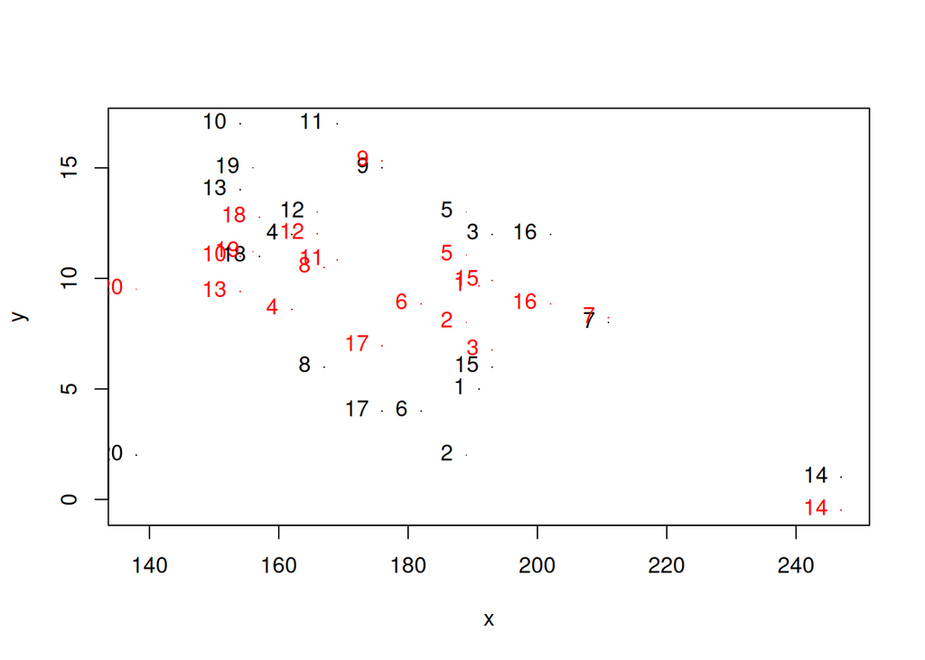

```r
# gráficos clásicos: ejemplo con el primero regresor
plot(x[,1],y,xlab="x",ylab="y",ylim=c(min(y,eta),max(y,eta)),pch=".")
  text(x[,1],y,labels=lab,pos=2)
  points(x[,1],eta,col="red",pch=".")
  text(x[,1],eta,labels=lab,col="red",pos=2)
```

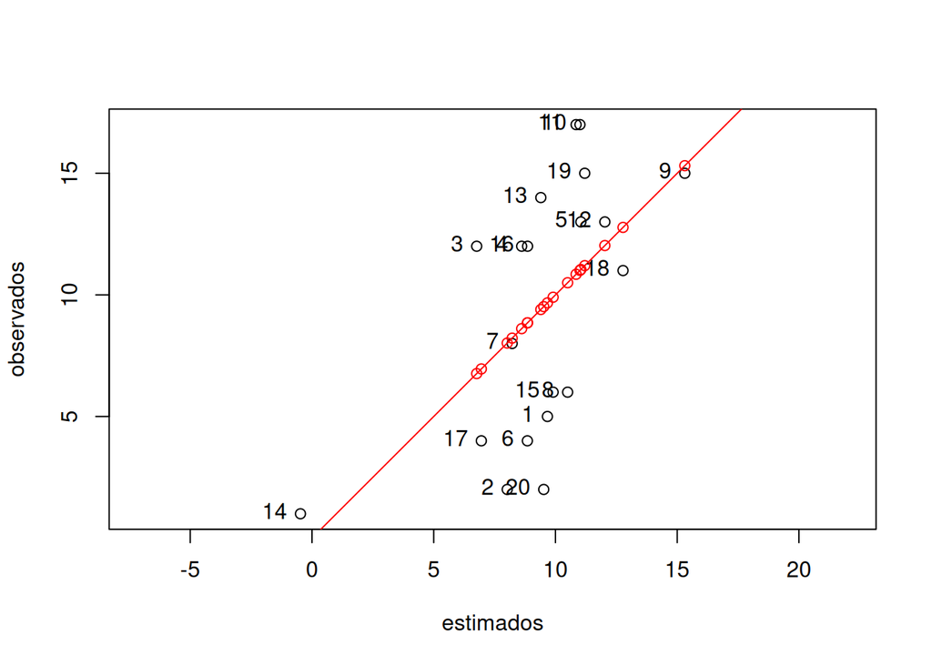

```r
# gráficos de valores estimados y residuos
plot(eta,y,asp=1,xlab="estimados",ylab="observados")
  abline(0,1,col="red")
  text(eta,y,labels=lab,pos=2)
  points(eta,eta,col="red")
```

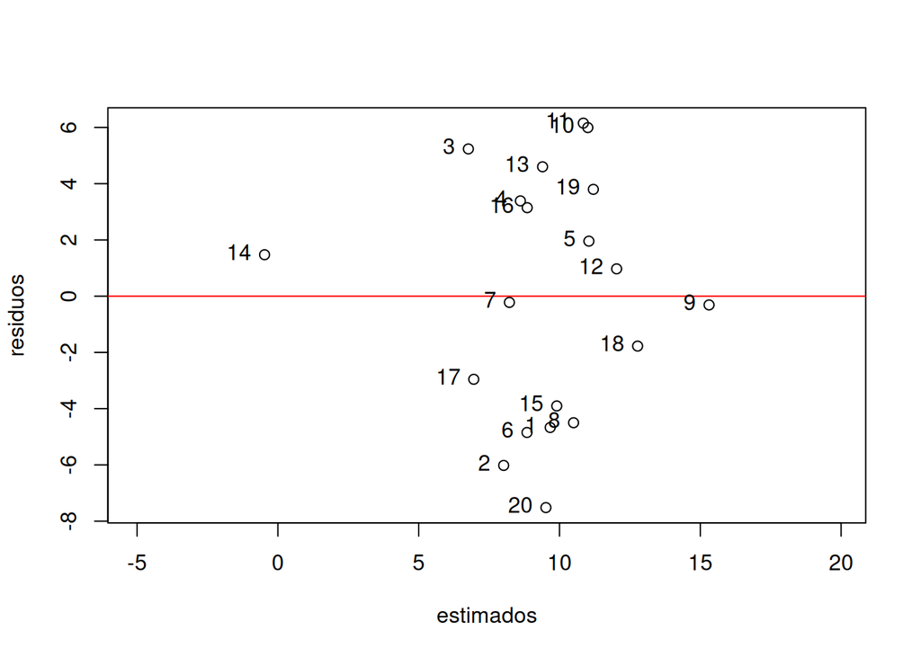

```r
plot(eta,res,asp=1,xlab="estimados",ylab="residuos")
  abline(0,0,col="red")
  text(eta,res,labels=lab,pos=2)
```

```r
# datos para anova
ssr   <- t(eta) %*% eta            # suma de  cuadrados por regresión
sse   <- ssy - ssr                 # suma por residuos
msr   <- ssr/p1                    # cuadrado promedio por regresión
mse   <- sse/(n-p1)                # cuadrado promedio por residuos
df    <- c(p1,n-p1,n)              # grados de libertad
ssq   <- c(ssr,sse,ssy)            # sumas de cuadrados
msq   <- c(msr,mse,0)              # suma de residuos
anova <- (cbind(df,ssq,msq))       # tabla de anova
colnames(anova) <- c("Degrees of Freedom","Sum of squares","Mean squares")
rownames(anova) <- c("Regression","Residuals","Total")
cat("\n Table ANOVA \n")
```

```
##
##  Table ANOVA
```

```r
anova
```

```
##            Degrees of Freedom Sum of squares Mean squares
## Regression                  4      1966.3455    491.58638
## Residuals                  16       350.6545     21.91591
## Total                      20      2317.0000      0.00000
```

```r
# apalancamiento
Hat   <- X %*% XXm1 %*% t(X)                  # matriz H sombrero
rownames(Hat) <- lab                          # inclusivo de su etiquetas
colnames(Hat) <- lab
# Hat
lev   <- diag(Hat)                            # apalancamientos
pesos <- cbind(x,y,lev)                       # construcción de una salida conjunta
rownames(pesos) <- lab
pesos                                         # salida
```

```
##    Weight Waist Pulse  y        lev
## 1     191    36    50  5 0.10655710
## 2     189    37    52  2 0.07274466
## 3     193    38    58 12 0.10454362
## 4     162    35    62 12 0.14458388
## 5     189    35    46 13 0.21767716
## 6     182    36    56  4 0.05211761
## 7     211    38    56  8 0.17497701
## 8     167    34    60  6 0.06993305
## 9     176    31    74 15 0.71976680
## 10    154    33    56 17 0.11322903
## 11    169    34    50 17 0.12146711
## 12    166    33    52 13 0.12293309
## 13    154    34    64 14 0.18069260
## 14    247    46    50  1 0.63478590
## 15    193    36    46  6 0.18304599
## 16    202    37    62 12 0.19664999
## 17    176    37    54  4 0.13010298
## 18    157    32    52 11 0.16288488
## 19    156    33    54 15 0.11801577
## 20    138    33    68  2 0.37329175
```

```r
niv   <- 2 * p1 / n                           # nivel para apalancamiento
level <- which(lev>niv)                       # unidades con fuerte apalancamiento
out   <- rbind(level,lev[level])              # salida
rownames(out) <- c("unidad","apalancamiento")
cat("\n Apalancamientos \n")
```

```
##
##  Apalancamientos
```

```r
out
```

```
##                        9         14
## unidad         9.0000000 14.0000000
## apalancamiento 0.7197668  0.6347859
```

## 4 crear una función regre()

que executa los comandos derivados del archivo .R, ingresando y e X y saliendo los resultados y la tabla de analisis de la varianza, el apalancamiento de las unidades y los dos plot de valores observados y residuos contra los valores estimados.

```r
regre               <- function(y,x) {
  res               <- list()
  # definición de los datos para el modelo
  lab               <- rownames(x)
  n                 <- length(y)                            # n es el número de observaciones
  p                 <- dim(x)[2]                            # numero de regresores
  nomy              <- deparse(substitute(y))               # nomy es su nombre
  nom               <- c(colnames(x),nomy)                  # etiquetas variables en nom
  # estadísticas
  xm                <- apply(x,2,mean)                      # cálculo de xm, promedio de x
  ym                <- sum(y)/n                             # cálculo de ym, promedio de y
  ssx               <- apply(x^2,2,sum)                     # ssx es la suma de los x cuadros
  ssy               <- sum(y^2)                             # ssy es la suma de los y cuadros
  sxy               <- t(x)%*%y                             # sxy es la suma de los productos xy
  ssxc              <- ssx-n*xm^2                           # ssxc es ssx centrado sobre el promedio
  ssyc              <- ssy-n*ym^2                           # ssyc es ssy centrado sobre el promedio
  sxyc              <- sxy-n*xm*ym                          # sxyc es sxy centrado sobre el promedio
  varx              <- ssxc/n                               # varx es la varianza de x
  vary              <- ssyc/n                               # vary es la varianza de y
  covxy             <- sxyc/n                               # covxy es la covarianza de xy
  stats             <- matrix(8*(2*p+1)*0,nrow=8,ncol=(2*p+1)) # construcción de tabla de estadísticas
  rownames(stats)   <- c("Mínimo","Máximo","Promedio","Total","Suma de cuadrados",
                         "Cuadrados centrados","Varianza covarianza","Desvío estándar")
  colnames(stats)   <- c(nom,paste0("x",c(1:p),"y"))
  stats[1:8,1:p]    <- rbind(apply(x,2,min),apply(x,2,max),xm,apply(x,2,sum),
                             ssx,ssxc,varx,sqrt(varx))
  stats[,p+1]       <- rbind(min(y),max(y),ym,sum(y),ssy,ssyc,vary,sqrt(vary))
  stats[,c((p+2):(2*p+1))] <- rbind(t(rep(0,p)),t(rep(0,p)),t(rep(0,p)),t
                                    (rep(0,p)),t(sxy),t(sxyc),t(covxy),t(rep(0,p)))
  res$estadisticas  <- round(stats,3)                       # impresión de la tabla
  res$var_cov       <- (n-1)/n * cov(x)                     # matriz de varianza/covarianza de los x
  # estimación
  X                 <- cbind(rep(1,n),x)                    # se necesita ajuntar la columna de unos
  p1                <- p + 1                                # un regresor más
  XX                <- t(X)%*%X                             # matriz X'X
  XXm1              <- solve(XX)                            # su inversa
  bh                <- XXm1 %*% t(X) %*% y                  # estimación de los betas
  res$beta_h        <- bh
  eta               <- X %*% bh                             # valores estimados
  resid             <- y - eta                              # residuos
  # datos para anova
  ssr               <- t(eta) %*% eta                       # suma de  cuadrados por regresión
  sse               <- ssy - ssr                            # suma por residuos
  msr               <- ssr/p1                               # cuadrado promedio por regresión
  mse               <- sse/(n-p1)                           # cuadrado promedio por residuos
  df                <- c(p1,n-p1,n)                         # grados de libertad
  ssq               <- c(ssr,sse,ssy)                       # sumas de cuadrados
  msq               <- c(msr,mse,0)                         # suma de residuos
  ratio             <- c(msr/mse,0,0)
  anova             <- (cbind(df,ssq,msq,ratio))            # tabla de anova
  colnames(anova)   <- c("Degrees of Freedom","Sum of squares","Mean squares","Ratio")
  rownames(anova)   <- c("Regression","Residuals","Total")
  res$Anova         <- anova
  # apalancamiento
  Hat               <- X %*% XXm1 %*% t(X)                  # matriz H sombrero
  rownames(Hat)     <- lab                                  # inclusivo de su etiquetas
  colnames(Hat)     <- lab
  # Hat
  lev               <- diag(Hat)                            # apalancamientos
  unidad            <- cbind(x,y,eta,resid,lev)             # tabla de resultados
  rownames(unidad)  <- lab
  colnames(unidad)  <- c(nom,"eta","residuos","leverage")
  res$results       <- round(unidad,3)                      # impresión de la tabla

  # gráficos de valores estimados y residuos
  plot(eta,y,asp=1,xlab="estimados",ylab="observados")
    abline(0,1,col="red")
    text(eta,y,labels=lab,pos=2)
    points(eta,eta,col="red")
  plot(eta,resid,asp=1,xlab="estimados",ylab="residuos")
    abline(0,0,col="red")
    text(eta,resid,labels=lab,pos=2)
  #
  res
}
regre       <- function(y,x) {
res         <- list()
# definición de los datos para el modelo
lab   <- rownames(x)
n     <- length(y)                           # n es el número de observaciones
p     <- dim(x)[2]                           # numero de regresores
nomy  <- deparse(substitute(y))              # nomy es su nombre
nom   <- c(colnames(x),nomy)                 # etiquetas variables en nom
# estadísticas
xm    <- apply(x,2,mean)                     # cálculo de xm, promedio de x
ym    <- sum(y)/n                            # cálculo de ym, promedio de y
ssx   <- apply(x^2,2,sum)                    # ssx es la suma de los x cuadros
ssy   <- sum(y^2)                            # ssy es la suma de los y cuadros
sxy   <- t(x)%*%y                            # sxy es la suma de los productos xy
ssxc  <- ssx-n*xm^2                          # ssxc es ssx centrado sobre el promedio
ssyc  <- ssy-n*ym^2                          # ssyc es ssy centrado sobre el promedio
sxyc  <- sxy-n*xm*ym                         # sxyc es sxy centrado sobre el promedio
varx  <- ssxc/n                              # varx es la varianza de x
vary  <- ssyc/n                              # vary es la varianza de y
covxy <- sxyc/n                              # covxy es la covarianza de xy
stats <- matrix(8*(2*p+1)*0,nrow=8,ncol=(2*p+1)) # construcción de tabla de estadísticas
rownames(stats) <- c("Mínimo","Máximo","Promedio","Total","Suma de cuadrados",
                    "Cuadrados centrados","Varianza covarianza","Desvío estándar")
colnames(stats) <- c(nom,paste0("x",c(1:p),"y"))
stats[1:8,1:p] <- rbind(apply(x,2,min),apply(x,2,max),xm,apply(x,2,sum),ssx,ssxc,varx,sqrt(varx))
stats[,p+1] <- rbind(min(y),max(y),ym,sum(y),ssy,ssyc,vary,sqrt(vary))
stats[,c((p+2):(2*p+1))] <- rbind(t(rep(0,p)),t(rep(0,p)),t(rep(0,p)),t(rep(0,p)),t(sxy),t(sxyc),t(covxy),t(rep(0,p)))
res$estadisticas <- round(stats,3)           # impresión de la tabla
res$var_cov  <- vcovx <- (n-1)/n * cov(x)    # matriz de varianza/covarianza de los x
# estimación
X      <- cbind(rep(1,n),x)                  # se necesita ajuntar la columna de unos
p1     <- p + 1                              # un regresor más
XX     <- t(X)%*%X                           # matriz X'X
XXm1   <- solve(XX)                          # su inversa
bh     <- XXm1 %*% t(X) %*% y                # estimación de los betas
res$beta_h <- bh
eta    <- X %*% bh                           # valores estimados
resid  <- y - eta                            # residuos
# datos para anova
ssr   <- t(eta) %*% eta            # suma de  cuadrados por regresión
sse   <- ssy - ssr                 # suma por residuos
msr   <- ssr/p1                    # cuadrado promedio por regresión
mse   <- sse/(n-p1)                # cuadrado promedio por residuos
df    <- c(p1,n-p1,n)              # grados de libertad
ssq   <- c(ssr,sse,ssy)            # sumas de cuadrados
msq   <- c(msr,mse,0)              # suma de residuos
ratio <- c(msr/mse,0,0)
anova <- (cbind(df,ssq,msq,ratio)) # tabla de anova
colnames(anova) <- c("Degrees of Freedom","Sum of squares","Mean squares","Ratio")
rownames(anova) <- c("Regression","Residuals","Total")
res$Anova  <- anova
# apalancamiento
Hat   <- X %*% XXm1 %*% t(X)                  # matriz H sombrero
rownames(Hat) <- lab                          # inclusivo de su etiquetas
colnames(Hat) <- lab
# Hat
lev   <- diag(Hat)                            # apalancamientos
unidad <- cbind(x,y,eta,resid,lev)            # tabla de resultados
rownames(unidad) <- lab
colnames(unidad) <- c(nom,"eta","residuos","leverage")
res$results   <- round(unidad,3)              # impresión de la tabla

# gráficos de valores estimados y residuos
plot(eta,y,asp=1,xlab="estimados",ylab="observados")
  abline(0,1,col="red")
  text(eta,y,labels=lab,pos=2)
  points(eta,eta,col="red")
plot(eta,resid,asp=1,xlab="estimados",ylab="residuos")
  abline(0,0,col="red")
  text(eta,resid,labels=lab,pos=2)
#
  res
}
```

## 5 con la función modelar “Pulls” y “Squats”

y comentar los dos conjuntos de resultados: a través de las tablas de análisis de varianza, ¿cual modelo le parece mejor?

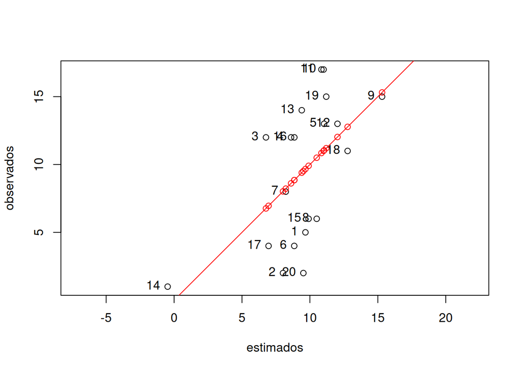

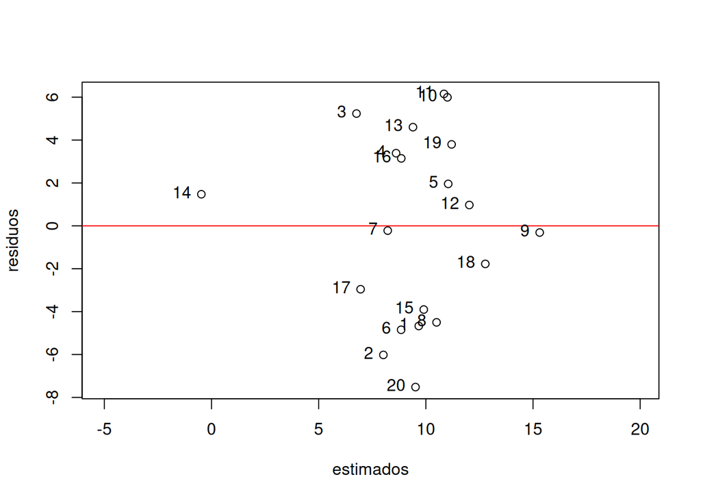

```
## $estadisticas
##                         Weight     Waist     Pulse lin$Pulls      x1y     x2y       x3y
## Mínimo                 138.000    31.000    46.000     1.000     0.00    0.00     0.000
## Máximo                 247.000    46.000    74.000    17.000     0.00    0.00     0.000
## Promedio               178.600    35.400    56.100     9.450     0.00    0.00     0.000
## Total                 3572.000   708.000  1122.000   189.000     0.00    0.00     0.000
## Suma de cuadrados   649542.000 25258.000 63932.000  2317.000 32789.00 6513.00 10712.000
## Cuadrados centrados  11582.800   194.800   987.800   530.950  -966.40 -177.60   109.100
## Varianza covarianza    579.140     9.740    49.390    26.548   -48.32   -8.88     5.455
## Desvío estándar         24.065     3.121     7.028     5.152     0.00    0.00     0.000
##
## $var_cov
##        Weight Waist  Pulse
## Weight 579.14 65.36 -61.86
## Waist   65.36  9.74  -7.74
## Pulse  -61.86 -7.74  49.39
##
## $beta_h
##               [,1]
##        47.96841291
## Weight  0.07884384
## Waist  -1.45584256
## Pulse  -0.01895002
##
## $Anova
##            Degrees of Freedom Sum of squares Mean squares    Ratio
## Regression                  4      1966.3455    491.58638 22.43058
## Residuals                  16       350.6545     21.91591  0.00000
## Total                      20      2317.0000      0.00000  0.00000
##
## $results
##    Weight Waist Pulse lin$Pulls    eta residuos leverage
## 1     191    36    50         5  9.670   -4.670    0.107
## 2     189    37    52         2  8.018   -6.018    0.073
## 3     193    38    58        12  6.764    5.236    0.105
## 4     162    35    62        12  8.612    3.388    0.145
## 5     189    35    46        13 11.044    1.956    0.218
## 6     182    36    56         4  8.846   -4.846    0.052
## 7     211    38    56         8  8.221   -0.221    0.175
## 8     167    34    60         6 10.500   -4.500    0.070
## 9     176    31    74        15 15.312   -0.312    0.720
## 10    154    33    56        17 11.006    5.994    0.113
## 11    169    34    50        17 10.847    6.153    0.121
## 12    166    33    52        13 12.028    0.972    0.123
## 13    154    34    64        14  9.399    4.601    0.181
## 14    247    46    50         1 -0.473    1.473    0.635
## 15    193    36    46         6  9.903   -3.903    0.183
## 16    202    37    62        12  8.854    3.146    0.197
## 17    176    37    54         4  6.955   -2.955    0.130
## 18    157    32    52        11 12.775   -1.775    0.163
## 19    156    33    54        15 11.202    3.798    0.118
## 20    138    33    68         2  9.517   -7.517    0.373
```

```r
(reg1               <- regre(y=lin$Pulls,as.matrix(lin[,1:3])))
```

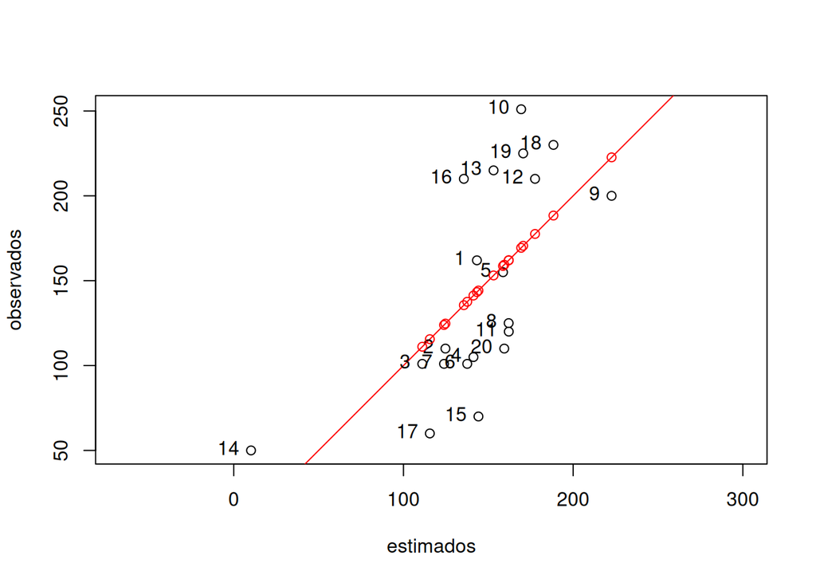

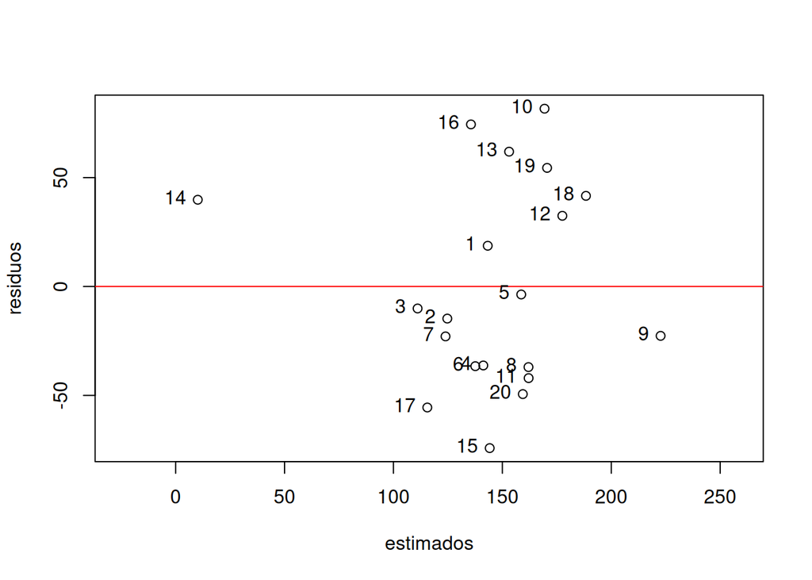

```
## $estadisticas
##                         Weight     Waist     Pulse lin$Squats       x1y       x2y        x3y
## Mínimo                 138.000    31.000    46.000     50.000      0.00      0.00      0.000
## Máximo                 247.000    46.000    74.000    251.000      0.00      0.00      0.000
## Promedio               178.600    35.400    56.100    145.550      0.00      0.00      0.000
## Total                 3572.000   708.000  1122.000   2911.000      0.00      0.00      0.000
## Suma de cuadrados   649542.000 25258.000 63932.000 498073.000 505432.00 100592.00 165236.000
## Cuadrados centrados  11582.800   194.800   987.800  74376.950 -14472.60  -2457.40   1928.900
## Varianza covarianza    579.140     9.740    49.390   3718.847   -723.63   -122.87     96.445
## Desvío estándar         24.065     3.121     7.028     60.982      0.00      0.00      0.000
##
## $var_cov
##        Weight Waist  Pulse
## Weight 579.14 65.36 -61.86
## Waist   65.36  9.74  -7.74
## Pulse  -61.86 -7.74  49.39
##
## $beta_h
##               [,1]
##        623.2817463
## Weight   0.7276600
## Waist  -17.3872206
## Pulse    0.1393189
##
## $Anova
##            Degrees of Freedom Sum of squares Mean squares    Ratio
## Regression                  4      456161.01     114040.3 43.53513
## Residuals                  16       41911.99       2619.5  0.00000
## Total                      20      498073.00          0.0  0.00000
##
## $results
##    Weight Waist Pulse lin$Squats     eta residuos leverage
## 1     191    36    50        162 143.291   18.709    0.107
## 2     189    37    52        110 124.727  -14.727    0.073
## 3     193    38    58        101 111.086  -10.086    0.105
## 4     162    35    62        105 141.248  -36.248    0.145
## 5     189    35    46        155 158.665   -3.665    0.218
## 6     182    36    56        101 137.578  -36.578    0.052
## 7     211    38    56        101 123.905  -22.905    0.175
## 8     167    34    60        125 161.995  -36.995    0.070
## 9     176    31    74        200 222.656  -22.656    0.720
## 10    154    33    56        251 169.365   81.635    0.113
## 11    169    34    50        120 162.057  -42.057    0.121
## 12    166    33    52        210 177.540   32.460    0.123
## 13    154    34    64        215 153.092   61.908    0.181
## 14    247    46    50         50  10.168   39.832    0.635
## 15    193    36    46         70 144.189  -74.189    0.183
## 16    202    37    62        210 135.580   74.420    0.197
## 17    176    37    54         60 115.546  -55.546    0.130
## 18    157    32    52        230 188.378   41.622    0.163
## 19    156    33    54        225 170.542   54.458    0.118
## 20    138    33    68        110 159.394  -49.394    0.373
```

```r
regre(y=lin$Squats,as.matrix(lin[,1:3]))
```

## 6 Correr el modelo para Pulls,

pero tirando las 2 unidades con apalancamiento más grande y comentar el cambio, incluyendo gráficos con valores estimados y errores en los dos casos (color diferente).

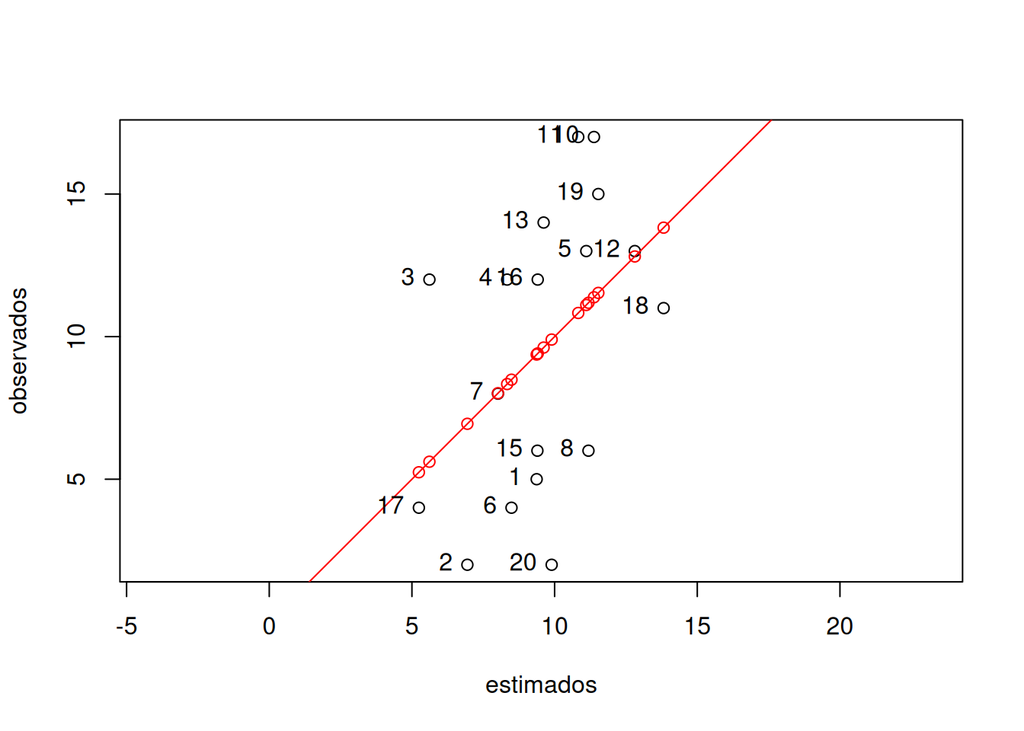

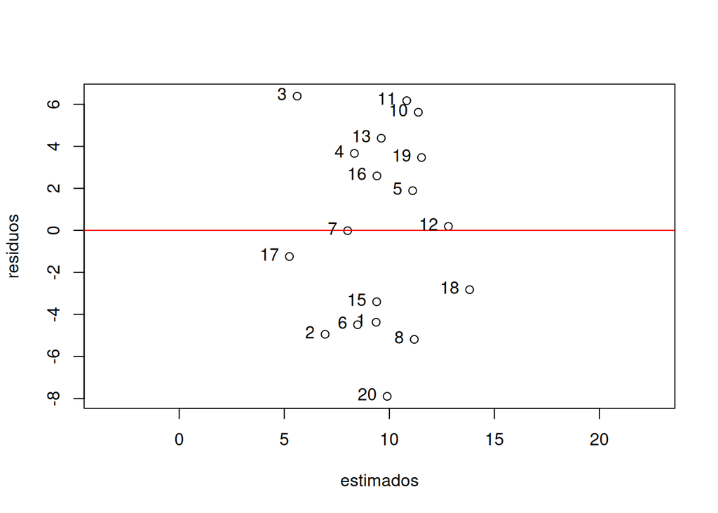

```
## $estadisticas
##                         Weight     Waist     Pulse lin$Pulls[-c(9, 14)]       x1y      x2y      x3y
## Mínimo                 138.000    32.000    46.000                2.000     0.000    0.000    0.000
## Máximo                 211.000    38.000    68.000               17.000     0.000    0.000    0.000
## Promedio               174.944    35.056    55.444                9.611     0.000    0.000    0.000
## Total                 3149.000   631.000   998.000              173.000     0.000    0.000    0.000
## Suma de cuadrados   557557.000 22181.000 55956.000             2091.000 29902.000 6002.000 9552.000
## Cuadrados centrados   6656.944    60.944   622.444              428.278  -363.389  -62.611  -39.889
## Varianza covarianza    369.830     3.386    34.580               23.793   -20.188   -3.478   -2.216
## Desvío estándar         19.231     1.840     5.880                4.878     0.000    0.000    0.000
##
## $var_cov
##           Weight      Waist       Pulse
## Weight 369.83025 30.4475309 -45.3641975
## Waist   30.44753  3.3858025  -0.8580247
## Pulse  -45.36420 -0.8580247  34.5802469
##
## $beta_h
##               [,1]
##        61.23658732
## Weight  0.14053819
## Waist  -2.27498972
## Pulse   0.06383284
##
## $Anova
##            Degrees of Freedom Sum of squares Mean squares   Ratio
## Regression                  4      1751.5456    437.88640 18.0596
## Residuals                  14       339.4544     24.24674  0.0000
## Total                      18      2091.0000      0.00000  0.0000
##
## $results
##    Weight Waist Pulse lin$Pulls[-c(9, 14)]    eta residuos leverage
## 1     191    36    50                    5  9.371   -4.371    0.118
## 2     189    37    52                    2  6.943   -4.943    0.177
## 3     193    38    58                   12  5.613    6.387    0.239
## 4     162    35    62                   12  8.337    3.663    0.153
## 5     189    35    46                   13 11.110    1.890    0.218
## 6     182    36    56                    4  8.490   -4.490    0.072
## 7     211    38    56                    8  8.015   -0.015    0.323
## 8     167    34    60                    6 11.187   -5.187    0.143
## 10    154    33    56                   17 11.379    5.621    0.131
## 11    169    34    50                   17 10.830    6.170    0.134
## 12    166    33    52                   13 12.811    0.189    0.178
## 13    154    34    64                   14  9.615    4.385    0.191
## 15    193    36    46                    6  9.397   -3.397    0.207
## 16    202    37    62                   12  9.408    2.592    0.501
## 17    176    37    54                    4  5.244   -1.244    0.429
## 18    157    32    52                   11 13.821   -2.821    0.262
## 19    156    33    54                   15 11.533    3.467    0.138
## 20    138    33    68                    2  9.897   -7.897    0.387
```

```r
(reg2               <- regre(y=lin$Pulls[-c(9,14)],as.matrix(lin[-c(9,14),1:3])))
```

## 7 mostrar la diferencia

entre betas y entre los residuos de los dos modelos.

*Los betas resultan los siguientes:*

```r
beta                <- cbind(reg1$beta_h, reg2$beta_h)
rownames(beta)[1]   <- "alpha"
colnames(beta)      <- c("todos","sin 9 y 14")
beta
```

```
##              todos  sin 9 y 14
## alpha  47.96841291 61.23658732
## Weight  0.07884384  0.14053819
## Waist  -1.45584256 -2.27498972
## Pulse  -0.01895002  0.06383284
```

*Las diferencias son muy relevantes.*

*Las tablas Anova brindan los siguientes resultados:*

```r
reg1$Anova
```

```
##            Degrees of Freedom Sum of squares Mean squares    Ratio
## Regression                  4      1966.3455    491.58638 22.43058
## Residuals                  16       350.6545     21.91591  0.00000
## Total                      20      2317.0000      0.00000  0.00000
```

```r
reg2$Anova
```

```
##            Degrees of Freedom Sum of squares Mean squares   Ratio
## Regression                  4      1751.5456    437.88640 18.0596
## Residuals                  14       339.4544     24.24674  0.0000
## Total                      18      2091.0000      0.00000  0.0000
```

*Se resulta que los residuos son más altos en el caso sin los atletas más lejos del baricentro. esto se nota tanto observando los cuadrados promedios como las dos razónes.*

*Se concluye que no conviene tirar estas observaciones.*

## 8 Decathlon: modelar “Points”

con las 4 velocidades, los 3 lanzamientos y los 3 saltos y comparar resultados.

```r
cat("\n regresión sobre velocidades \n")
```

```
##
##  regresión sobre velocidades
```

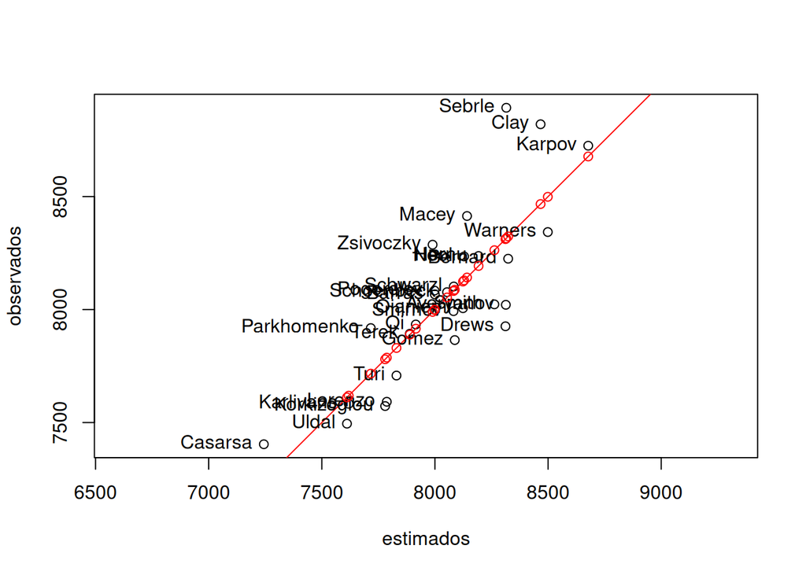

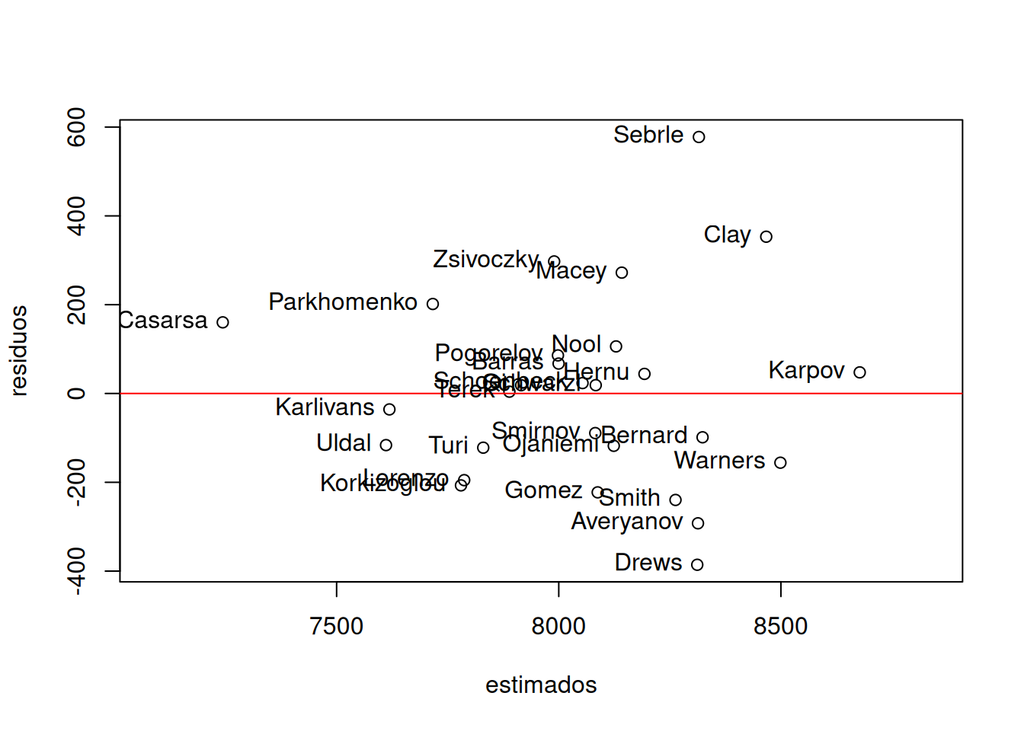

```
## $estadisticas
##                        X100m     X400m X110m.hurdle      X1500m   dec$Points         x1y          x2y         x3y          x4y
## Mínimo                10.440    46.810       13.970     263.080 7.404000e+03       0.000        0.000       0.000        0.000
## Máximo                11.360    53.200       15.390     317.000 8.893000e+03       0.000        0.000       0.000        0.000
## Promedio              10.916    49.610       14.554     277.551 8.051536e+03       0.000        0.000       0.000        0.000
## Total                305.640  1389.080      407.500    7771.420 2.254430e+05       0.000        0.000       0.000        0.000
## Suma de cuadrados   3337.720 68955.701     5935.872 2160424.133 1.818910e+09 2459212.410 11175237.960 3278092.120 62538969.490
## Cuadrados centrados    1.441    43.442        5.291    3460.961 3.747891e+06   -1658.966    -8989.270   -2908.684   -32896.191
## Varianza covarianza    0.051     1.552        0.189     123.606 1.338532e+05     -59.249     -321.045    -103.882    -1174.864
## Desvío estándar        0.227     1.246        0.435      11.118 3.658600e+02       0.000        0.000       0.000        0.000
##
## $var_cov
##                   X100m     X400m X110m.hurdle      X1500m
## X100m        0.05146735 0.1793786   0.05350816   0.1473852
## X400m        0.17937857 1.5515143   0.28150714   7.6335250
## X110m.hurdle 0.05350816 0.2815071   0.18898010   0.8653474
## X1500m       0.14738520 7.6335250   0.86534745 123.6057638
##
## $beta_h
##                      [,1]
##              22844.243133
## X100m         -596.688693
## X400m          -83.774840
## X110m.hurdle  -247.309189
## X1500m          -1.888384
##
## $Anova
##            Degrees of Freedom Sum of squares Mean squares    Ratio
## Regression                  5     1817686792 363537358.32 6834.161
## Residuals                  23        1223465     53194.15    0.000
## Total                      28     1818910257         0.00    0.000
##
## $results
##             X100m X400m X110m.hurdle X1500m dec$Points      eta residuos leverage
## Sebrle      10.85 48.36        14.05 280.01       8893 8315.359  577.641    0.167
## Clay        10.44 49.19        14.13 282.00       8820 8466.926  353.074    0.260
## Karpov      10.50 46.81        13.97 278.11       8725 8677.424   47.576    0.303
## Macey       10.89 48.97        14.56 265.42       8414 8141.813  272.187    0.082
## Warners     10.62 47.97        14.01 278.05       8343 8498.863 -155.863    0.138
## Zsivoczky   10.91 49.40        14.95 269.54       8287 7989.625  297.375    0.110
## Hernu       10.97 48.73        14.25 264.35       8237 8192.870   44.130    0.114
## Nool        10.80 48.81        14.80 276.33       8235 8128.962  106.038    0.102
## Bernard     10.69 49.13        14.17 276.31       8225 8323.632  -98.632    0.089
## Schwarzl    10.98 49.76        14.25 273.56       8102 8083.223   18.777    0.084
## Pogorelov   10.95 50.79        14.21 287.63       8084 7998.158   85.842    0.150
## Schoenbeck  10.90 50.30        14.34 278.82       8077 8053.529   23.471    0.089
## Barras      11.14 49.41        14.37 267.09       8067 7999.615   67.385    0.143
## Smith       10.85 49.27        14.01 272.74       8023 8262.745 -239.745    0.109
## Averyanov   10.55 49.72        14.39 271.02       8021 8313.323 -292.323    0.340
## Ojaniemi    10.68 49.12        15.01 275.71       8006 8123.830 -117.830    0.214
## Smirnov     10.89 49.11        14.77 263.31       7993 8082.134  -89.134    0.129
## Qi          11.06 49.65        14.78 272.63       7934 7915.385   18.615    0.064
## Drews       10.87 48.51        14.01 274.21       7926 8311.704 -385.704    0.126
## Parkhomenko 11.14 51.04        14.88 277.94       7918 7716.445  201.555    0.101
## Terek       10.92 49.56        15.12 290.36       7893 7888.895    4.105    0.223
## Gomez       11.08 48.61        14.41 269.70       7865 8087.615 -222.615    0.164
## Turi        11.08 51.67        14.26 290.01       7708 7830.007 -122.007    0.250
## Lorenzo     11.10 49.34        15.38 263.08       7592 7787.137 -195.137    0.277
## Karlivans   11.33 50.54        14.98 278.67       7583 7618.852  -35.852    0.174
## Korkizoglou 10.86 51.16        14.96 317.00       7573 7779.920 -206.920    0.538
## Uldal       11.23 50.95        15.09 281.70       7495 7611.248 -116.248    0.117
## Casarsa     11.36 53.20        15.39 296.12       7404 7243.761  160.239    0.343
```

```r
(dec1               <- regre(y=dec$Points,as.matrix(dec[,c(1,5,6,10)])))
```

```r
cat("\n regresión sobre lanzamientos \n")
```

```
##
##  regresión sobre lanzamientos
```

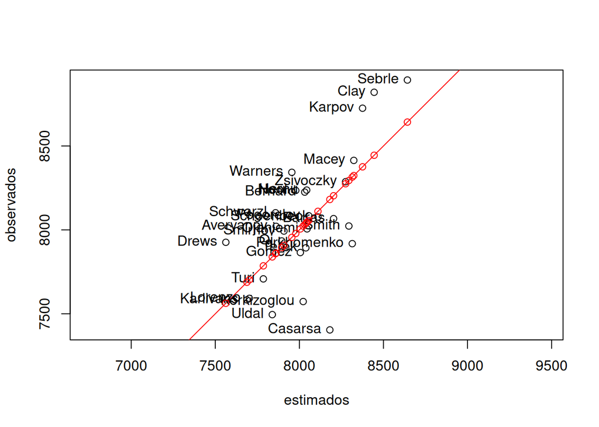

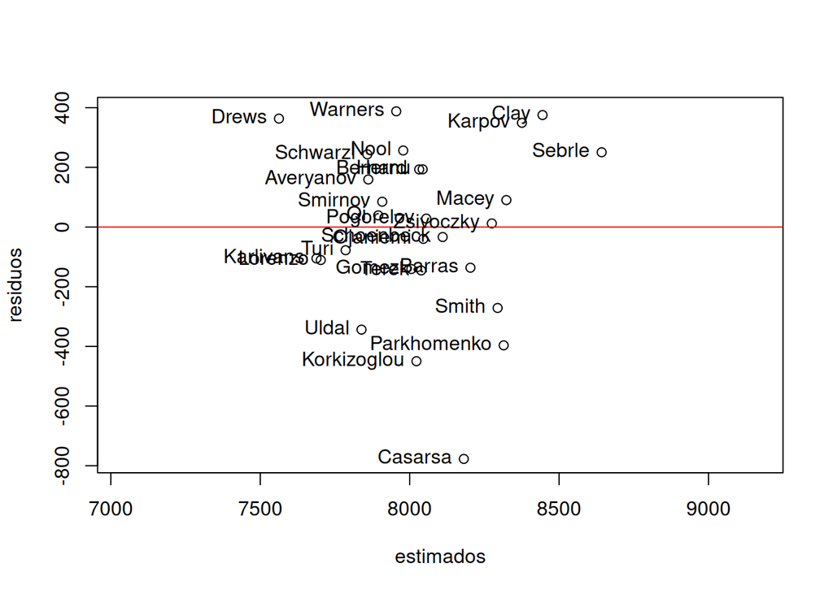

```
## $estadisticas
##                     Shot.put    Discus  Javeline   dec$Points         x1y          x2y          x3y
## Mínimo                13.070    39.830    50.620 7.404000e+03       0.000        0.000        0.000
## Máximo                16.360    51.650    70.520 8.893000e+03       0.000        0.000        0.000
## Promedio              14.625    44.376    58.949 8.051536e+03       0.000        0.000        0.000
## Total                409.500  1242.520  1650.570 2.254430e+05       0.000        0.000        0.000
## Suma de cuadrados   6008.732 55431.669 97967.828 1.818910e+09 3302451.610 10020966.520 13310718.270
## Cuadrados centrados   19.794   293.956   668.495 3.747891e+06    5347.735    16772.364    21094.966
## Varianza covarianza    0.707    10.498    23.875 1.338532e+05     190.991      599.013      753.392
## Desvío estándar        0.841     3.240     4.886 3.658600e+02       0.000        0.000        0.000
##
## $var_cov
##           Shot.put    Discus  Javeline
## Shot.put 0.7069321  1.813754  1.574877
## Discus   1.8137536 10.498439  4.034810
## Javeline 1.5748768  4.034810 23.874824
##
## $beta_h
##                [,1]
##          3547.74996
## Shot.put  186.40332
## Discus     18.66365
## Javeline   16.10588
##
## $Anova
##            Degrees of Freedom Sum of squares Mean squares    Ratio
## Regression                  4     1816811988 454202997.03 5195.174
## Residuals                  24        2098269     87427.87    0.000
## Total                      28     1818910257         0.00    0.000
##
## $results
##             Shot.put Discus Javeline dec$Points      eta residuos leverage
## Sebrle         16.36  48.72    70.52       8893 8642.388  250.612    0.292
## Clay           15.23  50.11    69.71       8820 8444.649  375.351    0.317
## Karpov         15.93  51.65    55.54       8725 8375.653  349.347    0.286
## Macey          15.73  48.34    58.46       8414 8323.625   90.375    0.120
## Warners        14.48  43.73    55.39       8343 7955.136  387.864    0.056
## Zsivoczky      15.31  45.62    63.45       8287 8274.939   12.061    0.077
## Hernu          14.65  44.72    57.76       8237 8043.473  193.527    0.039
## Nool           14.26  42.05    61.33       8235 7978.441  256.559    0.072
## Bernard        14.80  44.75    55.27       8225 8031.889  193.111    0.066
## Schwarzl       14.01  42.43    56.32       8102 7858.242  243.758    0.058
## Pogorelov      15.10  44.60    53.45       8084 8055.698   28.302    0.129
## Schoenbeck     14.77  44.41    60.89       8077 8110.467  -33.467    0.042
## Barras         14.91  44.83    64.55       8067 8203.349 -136.349    0.084
## Smith          15.24  49.02    61.52       8023 8294.262 -271.262    0.115
## Averyanov      14.44  39.88    54.51       8021 7861.652  159.348    0.165
## Ojaniemi       14.97  40.35    59.26       8006 8045.720  -39.720    0.189
## Smirnov        13.88  42.47    60.88       7993 7908.199   84.801    0.086
## Qi             13.55  45.13    60.79       7934 7894.882   39.118    0.201
## Drews          13.07  40.11    51.53       7926 7562.576  363.424    0.186
## Parkhomenko    15.69  41.90    65.82       7918 8314.514 -396.514    0.294
## Terek          15.15  45.62    50.62       7893 8038.476 -145.476    0.208
## Gomez          14.57  40.95    60.71       7865 8005.711 -140.711    0.108
## Turi           13.62  39.83    59.34       7708 7785.659  -77.659    0.122
## Lorenzo        13.22  40.22    58.36       7592 7702.593 -110.593    0.149
## Karlivans      13.30  43.34    52.92       7583 7688.120 -105.120    0.175
## Korkizoglou    14.81  46.07    53.05       7573 8022.634 -449.634    0.116
## Uldal          13.53  43.01    60.00       7495 7838.863 -343.863    0.130
## Casarsa        14.92  48.66    58.62       7404 8181.187 -777.187    0.118
```

```r
(dec2               <- regre(y=dec$Points,as.matrix(dec[,c(3,7,9)])))
```

```r
cat("\n regresión sobre saltos \n")
```

```
##
##  regresión sobre saltos
```

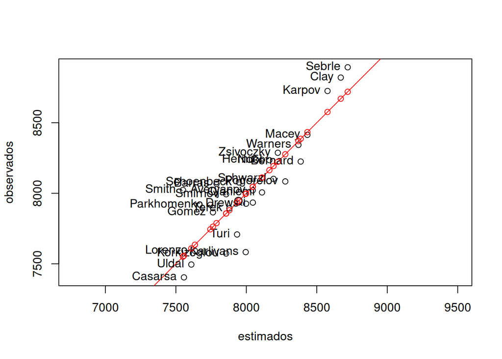

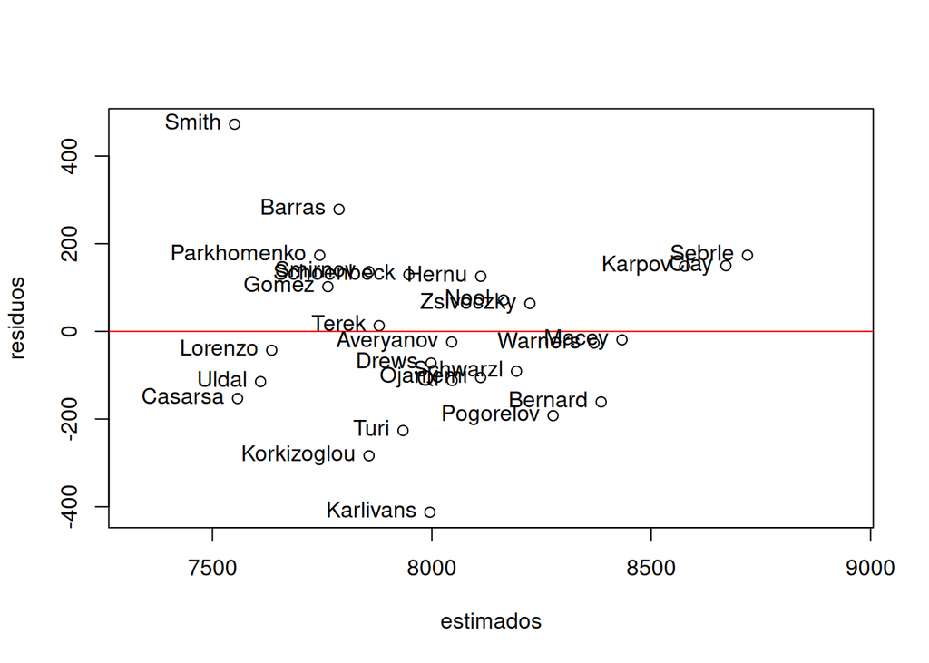

```
## $estadisticas
##                     Long.jump High.jump Pole.vault   dec$Points         x1y        x2y         x3y
## Mínimo                  6.610     1.850      4.200 7.404000e+03       0.000      0.000       0.000
## Máximo                  7.960     2.150      5.400 8.893000e+03       0.000      0.000       0.000
## Promedio                7.266     1.976      4.732 8.051536e+03       0.000      0.000       0.000
## Total                 203.440    55.340    132.500 2.254430e+05       0.000      0.000       0.000
## Suma de cuadrados    1481.279   109.594    629.270 1.818910e+09 1640639.700 446139.310 1067653.700
## Cuadrados centrados     3.142     0.218      2.261 3.747891e+06    2635.274    567.324     825.218
## Varianza covarianza     0.112     0.008      0.081 1.338532e+05      94.117     20.262      29.472
## Desvío estándar         0.335     0.088      0.284 3.658600e+02       0.000      0.000       0.000
##
## $var_cov
##             Long.jump    High.jump   Pole.vault
## Long.jump  0.11221735  0.010227551  0.027137755
## High.jump  0.01022755  0.007801531 -0.001063776
## Pole.vault 0.02713776 -0.001063776  0.080752551
##
## $beta_h
##                 [,1]
##            -919.7645
## Long.jump   632.9020
## High.jump  1791.3930
## Pole.vault  175.8727
##
## $Anova
##            Degrees of Freedom Sum of squares Mean squares   Ratio
## Regression                  4   1817991669.2 454497917.30 11874.7
## Residuals                  24       918587.8     38274.49     0.0
## Total                      28   1818910257.0         0.00     0.0
##
## $results
##             Long.jump High.jump Pole.vault dec$Points      eta residuos leverage
## Sebrle           7.84      2.12        5.0       8893 8719.304  173.696    0.199
## Clay             7.96      2.06        4.9       8820 8670.181  149.819    0.191
## Karpov           7.81      2.09        4.6       8725 8576.226  148.774    0.178
## Macey            7.47      2.15        4.4       8414 8433.348  -19.348    0.219
## Warners          7.74      1.97        4.9       8343 8369.717  -26.717    0.121
## Zsivoczky        7.14      2.12        4.7       8287 8223.511   63.489    0.169
## Hernu            7.19      2.03        4.8       8237 8111.518  125.482    0.063
## Nool             7.53      1.88        5.4       8235 8163.519   71.481    0.278
## Bernard          7.48      2.12        4.4       8225 8385.936 -160.936    0.181
## Schwarzl         7.49      1.94        5.1       8102 8192.925  -90.925    0.108
## Pogorelov        7.31      2.06        5.0       8084 8276.382 -192.382    0.113
## Schoenbeck       7.30      1.88        5.0       8077 7947.602  129.398    0.109
## Barras           6.99      1.94        4.6       8067 7788.537  278.463    0.063
## Smith            6.81      1.91        4.2       8023 7550.524  472.476    0.198
## Averyanov        7.34      1.94        4.8       8021 8045.228  -24.228    0.048
## Ojaniemi         7.50      1.94        4.6       8006 8111.317 -105.317    0.094
## Smirnov          7.07      1.94        4.7       7993 7856.757  136.243    0.050
## Qi               7.34      1.97        4.5       7934 8046.208 -112.208    0.071
## Drews            7.38      1.88        5.0       7926 7998.235  -72.235    0.116
## Parkhomenko      6.61      2.03        4.8       7918 7744.435  173.565    0.279
## Terek            6.94      1.94        5.3       7893 7880.003   12.997    0.274
## Gomez            7.26      1.85        4.4       7865 7763.021  101.979    0.195
## Turi             6.91      2.03        4.8       7708 7934.305 -226.305    0.134
## Lorenzo          7.03      1.85        4.5       7592 7635.041  -43.041    0.137
## Karlivans        7.26      1.97        4.5       7583 7995.575 -412.575    0.063
## Korkizoglou      7.07      1.94        4.7       7573 7856.757 -283.757    0.050
## Uldal            6.99      1.85        4.5       7495 7609.725 -114.725    0.137
## Casarsa          6.68      1.94        4.4       7404 7557.163 -153.163    0.163
```

```r
(dec3               <- regre(y=dec$Points,as.matrix(dec[,c(2,4,8)])))
```

¿Cual modelo entre los 3 le parece mejor?

```r
cat("\n regresión sobre velocidades \n")
```

```
##
##  regresión sobre velocidades
```

```r
dec1$Anova
```

```
##            Degrees of Freedom Sum of squares Mean squares    Ratio
## Regression                  5     1817686792 363537358.32 6834.161
## Residuals                  23        1223465     53194.15    0.000
## Total                      28     1818910257         0.00    0.000
```

```r
cat("\n regresión sobre lanzamientos \n")
```

```
##
##  regresión sobre lanzamientos
```

```r
dec2$Anova
```

```
##            Degrees of Freedom Sum of squares Mean squares    Ratio
## Regression                  4     1816811988 454202997.03 5195.174
## Residuals                  24        2098269     87427.87    0.000
## Total                      28     1818910257         0.00    0.000
```

```r
cat("\n regresión sobre saltos \n")
```

```
##
##  regresión sobre saltos
```

```r
dec3$Anova
```

```
##            Degrees of Freedom Sum of squares Mean squares   Ratio
## Regression                  4   1817991669.2 454497917.30 11874.7
## Residuals                  24       918587.8     38274.49     0.0
## Total                      28   1818910257.0         0.00     0.0
```

*Las razones muy altas indican que sin embargo los resultados son muy buenos. De todo modo, la regresión sobre saltos resulta con razón entre cuadrados promedios casi el doble de las demás.*

*Además, la regresión sobre velocidades, aún con cuatro regresores en vez de tres, no resulta la mejor.*

## 9 observar los apalancamientos

y seleccionar, entre los tres grupos de Decathlon (incluida la columna 1), el conjunto con los dos mayores y correr el modelo sin las dos unidades correspondientes.

```r
l1                  <- which(dec1$results[,7]==max(abs(dec1$results[,7])))
l2                  <- which(dec2$results[,7]==max(abs(dec2$results[,7])))
l3                  <- which(dec3$results[,7]==max(abs(dec3$results[,7])))
sort(dec1$results[,7], decreasing=TRUE)[1:2]
```

```
##  Sebrle    Clay
## 577.641 353.074
```

```r
sort(dec2$results[,7], decreasing=TRUE)[1:2]
```

```
##        Clay Parkhomenko
##       0.317       0.294
```

```r
sort(dec3$results[,7], decreasing=TRUE)[1:2]
```

```
## Parkhomenko        Nool
##       0.279       0.278
```

```r
which(rownames(dec) == c("Sebrle","Clay"))
```

```
## [1] 1 2
```

```r
cat("\n regresión sobre velocidades sin Sebrle y Clay \n")
```

```
##
##  regresión sobre velocidades sin Sebrle y Clay
```

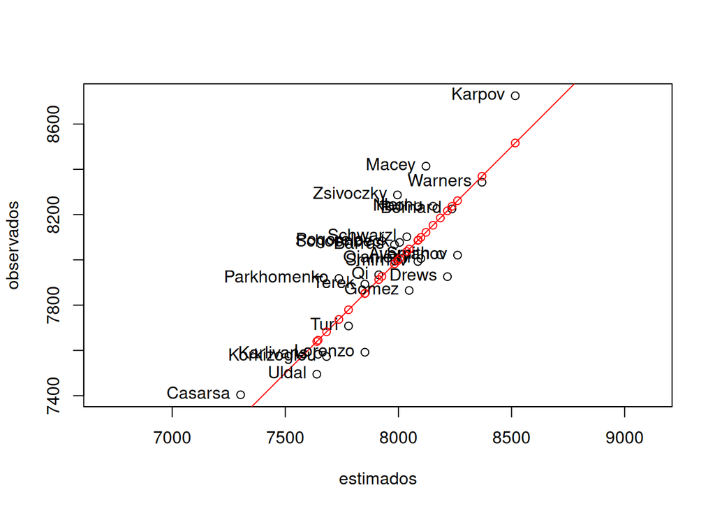

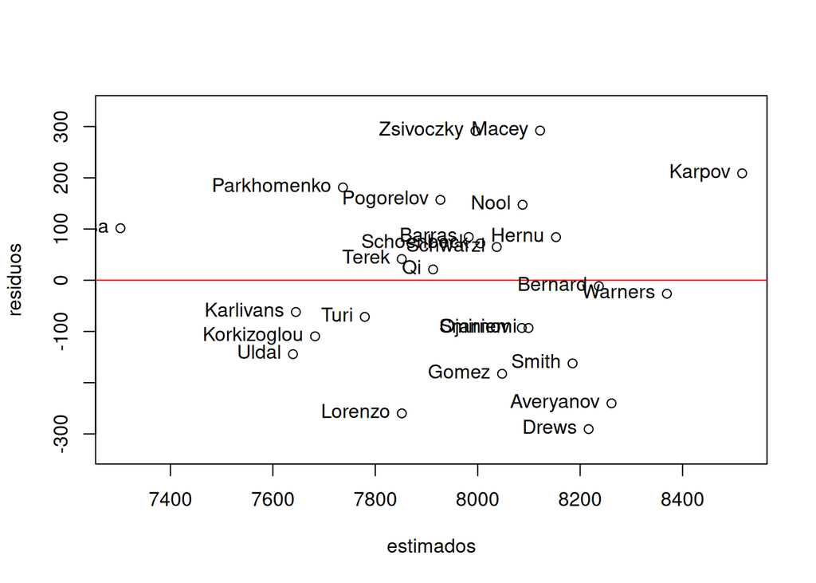

```
## $estadisticas
##                        X100m     X400m X110m.hurdle      X1500m dec$Points[-c(1:2)]         x1y          x2y         x3y          x4y
## Mínimo                10.500    46.810       13.970     263.080        7.404000e+03       0.000        0.000       0.000        0.000
## Máximo                11.360    53.200       15.390     317.000        8.725000e+03       0.000        0.000       0.000        0.000
## Promedio              10.937    49.674       14.589     277.285        7.989615e+03       0.000        0.000       0.000        0.000
## Total                284.350  1291.530      379.320    7209.410        2.077300e+05       0.000        0.000       0.000        0.000
## Suma de cuadrados   3111.004 64197.355     5538.812 2002494.533        1.662032e+09 2270642.560 10311316.680 3028518.870 57561600.560
## Cuadrados centrados    1.199    41.596        4.825    3433.281        2.349604e+06   -1204.575    -7511.278   -2102.038   -38812.490
## Varianza covarianza    0.046     1.600        0.186     132.049        9.036939e+04     -46.330     -288.895     -80.848    -1492.788
## Desvío estándar        0.215     1.265        0.431      11.491        3.006150e+02       0.000        0.000       0.000        0.000
##
## $var_cov
##                   X100m     X400m X110m.hurdle      X1500m
## X100m        0.04612263 0.1809954   0.04785888   0.2518788
## X400m        0.18099541 1.5998552   0.26981864   8.4278942
## X110m.hurdle 0.04785888 0.2698186   0.18559172   1.0615038
## X1500m       0.25187885 8.4278942   1.06150385 132.0492865
##
## $beta_h
##                      [,1]
##              21007.657628
## X100m         -543.974567
## X400m          -64.702094
## X110m.hurdle  -174.183231
## X1500m          -4.737427
##
## $Anova
##            Degrees of Freedom Sum of squares Mean squares    Ratio
## Regression                  5   1661374068.2 332274813.65 10599.04
## Residuals                  21       658339.8     31349.51     0.00
## Total                      26   1662032408.0         0.00     0.00
##
## $results
##             X100m X400m X110m.hurdle X1500m dec$Points[-c(1:2)]      eta residuos leverage
## Karpov      10.50 46.81        13.97 278.11                8725 8516.354  208.646    0.349
## Macey       10.89 48.97        14.56 265.42                8414 8121.797  292.203    0.083
## Warners     10.62 47.97        14.01 278.05                8343 8369.340  -26.340    0.168
## Zsivoczky   10.91 49.40        14.95 269.54                8287 7995.646  291.354    0.113
## Hernu       10.97 48.73        14.25 264.35                8237 8152.874   84.126    0.120
## Nool        10.80 48.81        14.80 276.33                8235 8087.618  147.382    0.105
## Bernard     10.69 49.13        14.17 276.31                8225 8236.581  -11.581    0.114
## Schwarzl    10.98 49.76        14.25 273.56                8102 8037.159   64.841    0.088
## Pogorelov   10.95 50.79        14.21 287.63                8084 7927.147  156.853    0.162
## Schoenbeck  10.90 50.30        14.34 278.82                8077 8005.143   71.857    0.100
## Barras      11.14 49.41        14.37 267.09                8067 7982.518   84.482    0.157
## Smith       10.85 49.27        14.01 272.74                8023 8185.269 -162.269    0.120
## Averyanov   10.55 49.72        14.39 271.02                8021 8261.304 -240.304    0.438
## Ojaniemi    10.68 49.12        15.01 275.71                8006 8099.196  -93.196    0.238
## Smirnov     10.89 49.11        14.77 263.31                7993 8086.157  -93.157    0.133
## Qi          11.06 49.65        14.78 272.63                7934 7912.847   21.153    0.067
## Drews       10.87 48.51        14.01 274.21                7926 8216.599 -290.599    0.147
## Parkhomenko 11.14 51.04        14.88 277.94                7918 7736.819  181.181    0.102
## Terek       10.92 49.56        15.12 290.36                7893 7851.610   41.390    0.227
## Gomez       11.08 48.61        14.41 269.70                7865 8047.586 -182.586    0.196
## Turi        11.08 51.67        14.26 290.01                7708 7779.508  -71.508    0.256
## Lorenzo     11.10 49.34        15.38 263.08                7592 7851.878 -259.878    0.286
## Karlivans   11.33 50.54        14.98 278.67                7583 7644.938  -61.938    0.201
## Korkizoglou 10.86 51.16        14.96 317.00                7573 7682.389 -109.389    0.556
## Uldal       11.23 50.95        15.09 281.70                7495 7639.293 -144.293    0.123
## Casarsa     11.36 53.20        15.39 296.12                7404 7302.428  101.572    0.349
```

```r
(dec4               <- regre(y=dec$Points[-c(1:2)],as.matrix(dec[-c(1:2),c(1,5,6,10)])))
```

```r
beta                <- cbind(dec1$beta_h, dec4$beta_h)
rownames(beta)[1]   <- "alpha"
colnames(beta)      <- c("todos","sin 1 y 2")
beta
```

```
##                     todos    sin 1 y 2
## alpha        22844.243133 21007.657628
## X100m         -596.688693  -543.974567
## X400m          -83.774840   -64.702094
## X110m.hurdle  -247.309189  -174.183231
## X1500m          -1.888384    -4.737427
```

```r
cat("\n regresión sobre velocidades \n")
```

```
##
##  regresión sobre velocidades
```

```r
dec1$Anova
```

```
##            Degrees of Freedom Sum of squares Mean squares    Ratio
## Regression                  5     1817686792 363537358.32 6834.161
## Residuals                  23        1223465     53194.15    0.000
## Total                      28     1818910257         0.00    0.000
```

```r
cat("\n regresión sin Sebrle y Clay \n")
```

```
##
##  regresión sin Sebrle y Clay
```

```r
dec4$Anova
```

```
##            Degrees of Freedom Sum of squares Mean squares    Ratio
## Regression                  5   1661374068.2 332274813.65 10599.04
## Residuals                  21       658339.8     31349.51     0.00
## Total                      26   1662032408.0         0.00     0.00
```

*En este caso también se observa un cambio relevante de los betas sin Sebrle y Clay. En este caso el residuo promedio baja mucho, mientras la razón aumenta mucho. Por lo tanto, se concluye que los dos atletas influyen sobre la regresión de manera tal vez anómala con respecto a los demás.*

## 10 en Rmarkdown,

comentar los resultados y paso a paso.

*Hecho*

## 11 guardar los archivos

.Rmd y .html y enviar-los a sergio@camiz.it dentro de las 23.59pm del 27 de Abril.